# Introduction to Machine Learning and Hybrid Intelligent Systems

## Denis Torgunov

### University of Bradford

#### 21st February 2018

```
dtorgunov
```

```
D.Torgunov@bradford.ac.uk
```

[figure not shown]

# What is Machine Learning?

- Machine Learning (ML) is a multidisciplinary approach to pattern recognition, commonly used to "make sense" of large volumes of data by learning from the data themselves
- It is impor that solutions generalise to new data
- ML is one of the tools used with Big Data, both to learn about the data as well as to make decisions based on it

# Binary Classification & Regression

- Binary Classification

  Find a model or function ("classifier") that will assign a class or label to any given input. The case where there are only two classes i known as "binary classification"

  $$y = f(\mathbf{x}) \quad \text{where} \quad y \in \{c_1, c_2\}$$
- Regression

  Find a model or function that maps a given input to a continuous output

  $$y = f(\mathbf{x}) \quad \text{where} \quad y \in \mathbb{R}$$

# Example data sets

For the purposes of illustrating the algorithms discussed, we will consider a few artificially created data sets, split into training and testing data. The first two are generated using the `datasets` module from `sci-learn`.

The final data set is devised by [Lang and Witbrock (1988)](https://www.researchgate.net/publication/269337640_Learning_to_Tell_Two_Spirals_Apart), and generated using the C code provided by them.

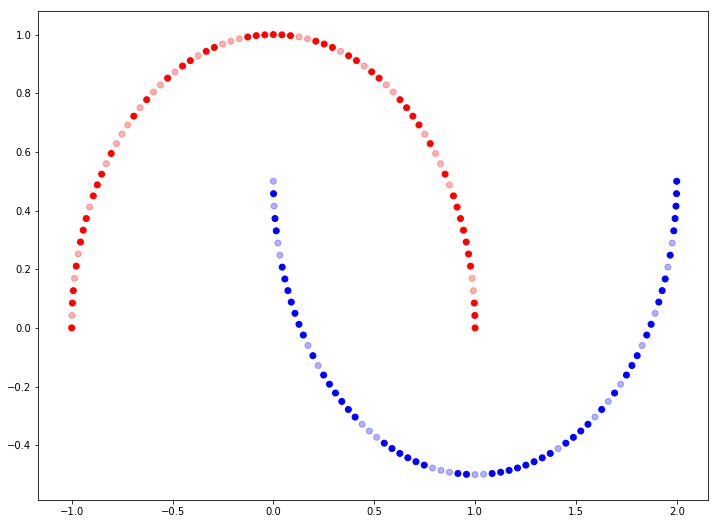

```python
(points, labels) = datasets.make_moons(n_samples = 150)
training_moon_p = points[0:100:1]; training_moon_l = labels[0:100:1]
testing_moon_p = points[100:150:1]; testing_moon_l = labels[100:150:1]
fig, ax = plt.subplots(); plot_data(ax, (training_moon_p, training_moon_l),
                                  (testing_moon_p, testing_moon_l))
```

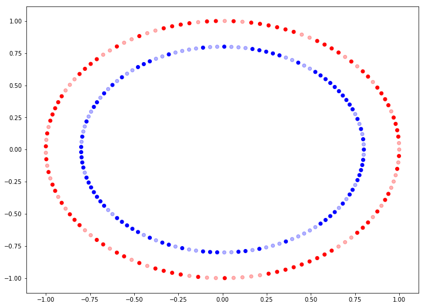

```python
(points, labels) = datasets.make_circles(n_samples = 250, shuffle=True, noise=None)
training_circ_p = points[0:150:1]; training_circ_l = labels[0:150:1]
testing_circ_p = points[150:250:1]; testing_circ_l = labels[150:250:1]
fig, ax = plt.subplots(); plot_data(ax, (training_circ_p, training_circ_l),
                                  (testing_circ_p, testing_circ_l))
```

```python
def load_spirals():
    data = np.loadtxt('data/two-spirals.csv', delimiter=',')

    # shuffle the data set (so that training and testing are not "in order")
    # with a reproducable random seed
    np.random.seed(12345)
    np.random.shuffle(data)

    points = np.transpose(np.array((np.transpose(data)[0], np.transpose(data)[1])))
    labels = np.transpose(data)[2]
    return (points, labels)
```

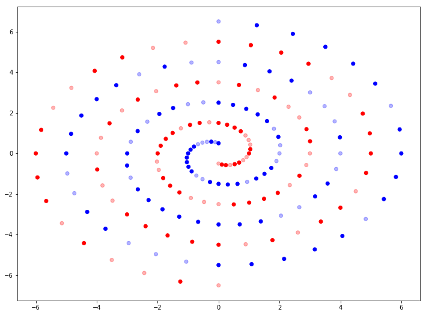

```python
(points, labels) = load_spirals()
training_spir_p = points[0:120:1]; training_spir_l = labels[0:120:1]
testing_spir_p = points[120:194:1]; testing_spir_l = labels[120:194:1]
fig, ax = plt.subplots(); plot_data(ax, (training_spir_p, training_spir_l),
                                        (testing_spir_p, testing_spir_l))
```

# Support Vector Machines

Suppor Vector Machines (SVMs) construct separating hyperplanes between classes, aiming to maximise the margin of separation.

[figure not shown]

```python
clf = svm.LinearSVC(random_state=12345)
clf.fit(training_moon_p, training_moon_l)
HTML('<h3> Testing data accuracy: ' + str(clf.score(testing_moon_p, testing_moon_l)) + '</h3>')
```

Testing data accuracy: 0.88

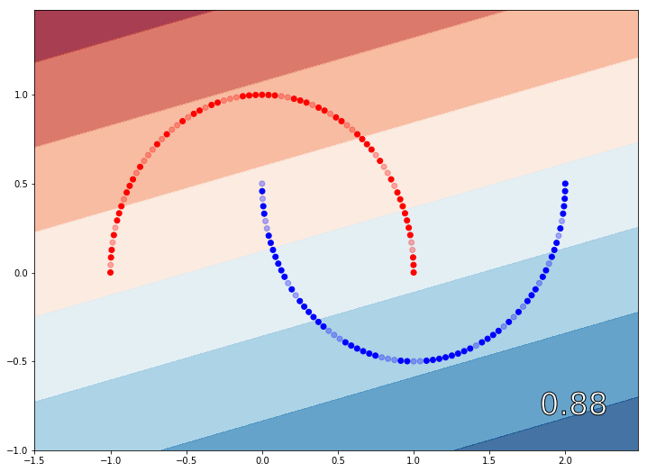

```python
fig, ax = plt.subplots()
plot_data(ax,
          (training_moon_p, training_moon_l),
          (testing_moon_p, testing_moon_l), clf)
```

```python
clf = svm.LinearSVC(random_state=12345)
clf.fit(training_circ_p, training_circ_l)
HTML('<h3> Testing data accuracy: ' + str(clf.score(testing_circ_p, testing_circ_l)) + '</h3>')
```

Testing data accuracy: 0.49

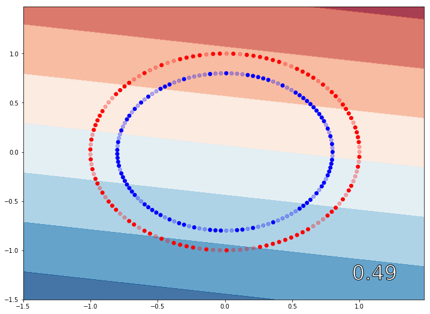

```python
fig, ax = plt.subplots()
plot_data(ax, (training_circ_p, training_circ_l),
          (testing_circ_p, testing_circ_l), clf)
```

```python
clf = svm.LinearSVC(random_state=12345)
clf.fit(training_spir_p, training_spir_l)
HTML('<h3> Testing data accuracy: ' + str(clf.score(testing_spir_p, testing_spir_l)) + '</h3>')
```

Testing data accuracy: 0.5405405405405406

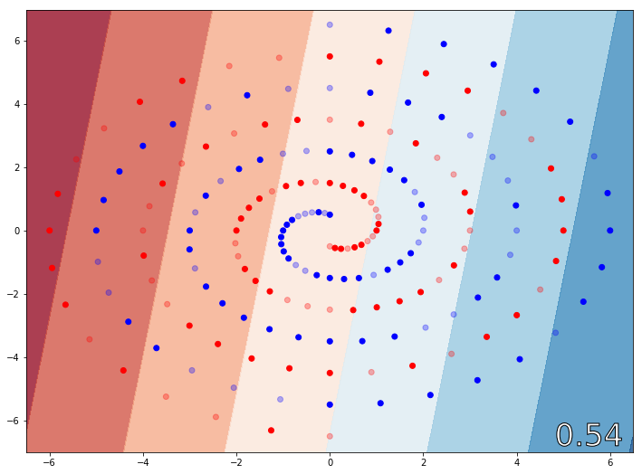

```python
fig, ax = plt.subplots()
plot_data(ax, (training_spir_p, training_spir_l),
          (testing_spir_p, testing_spir_l), clf)
```

# The Kernel Trick

A techinque known as the *Kernel Trick* can be utilised to classify patterns which are not linearly separable by mapping them to a (often higher-dimensional) feature space in which they can be separated by a hyperplane

[figure not shown]

```python
clf = svm.SVC(gamma='auto', C=100.0, random_state=12345)
clf.fit(training_moon_p, training_moon_l)
HTML('<h3> Testing data accuracy: ' + str(clf.score(testing_moon_p, testing_moon_l)) + '</h3>')
```

Testing data accuracy: 1.0

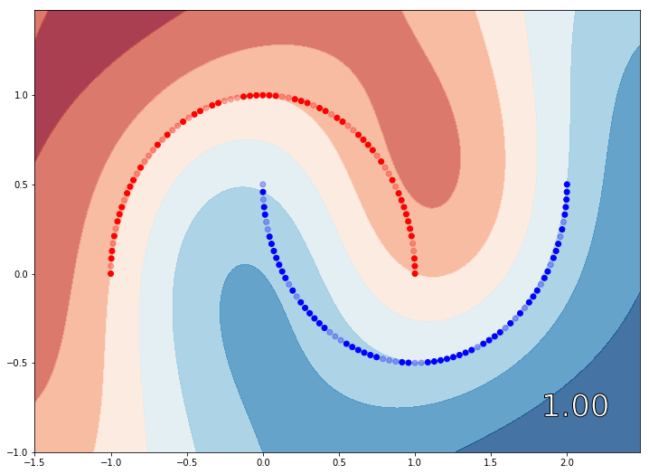

```python
fig, ax = plt.subplots()
plot_data(ax, (training_moon_p, training_moon_l),
          (testing_moon_p, testing_moon_l), clf)
```

```python
clf = svm.SVC(gamma='auto', C=100.0, random_state=12345)
clf.fit(training_circ_p, training_circ_l)
HTML('<h3> Testing data accuracy: ' + str(clf.score(testing_circ_p, testing_circ_l)) + '</h3>')
```

Testing data accuracy: 1.0

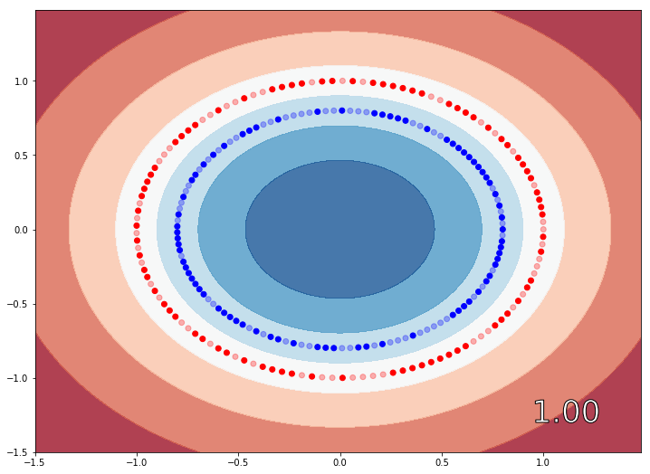

```python
fig, ax = plt.subplots()
plot_data(ax, (training_circ_p, training_circ_l),
          (testing_circ_p, testing_circ_l), clf)
```

```python
clf = svm.SVC(gamma='auto', C=100.0, random_state=12345)
clf.fit(training_spir_p, training_spir_l)
HTML('<h3> Testing data accuracy: ' + str(clf.score(testing_spir_p, testing_spir_l)) + '</h3>')
```

Testing data accuracy: 0.7432432432432432

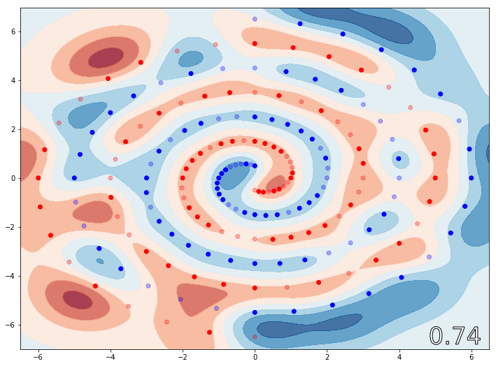

```python
fig, ax = plt.subplots()
plot_data(ax, (training_spir_p, training_spir_l),
          (testing_spir_p, testing_spir_l), clf)
```

The results for spiral are particularly poor (due to a few places where the spirals are "broken" in the training set, leading to incorrect generalisation). When presented with the full data set, we can see that the spiral shape itself can be learned.

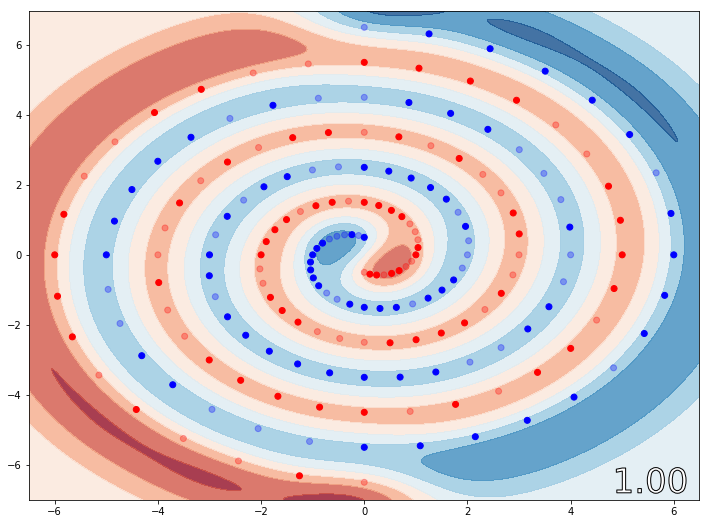

```python
clf = svm.SVC(gamma='auto', C=100.0, random_state=12345)
clf.fit(points, labels); fig, ax = plt.subplots(); plot_data(ax,
            (training_spir_p, training_spir_l), (testing_spir_p, testing_spir_l), clf)
```

# Result summary

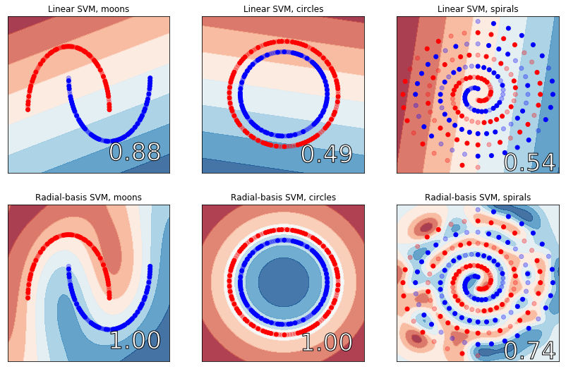

```python
summary_svm()
```

```python
(points, labels) = datasets.make_moons(n_samples = 150)
training_moon_p = points[0:100:1]; training_moon_l = labels[0:100:1]
testing_moon_p = points[100:150:1]; testing_moon_l = labels[100:150:1]
```

```python
(points, labels) = datasets.make_circles(n_samples = 250, shuffle=True, noise=None)
training_circ_p = points[0:150:1]; training_circ_l = labels[0:150:1]
testing_circ_p = points[150:250:1]; testing_circ_l = labels[150:250:1]
```

```python
def load_spirals():
    data = np.loadtxt('data/two-spirals.csv', delimiter=',')

    # shuffle the data set (so that training and testing are not "in order")
    # with a reproducable random seed
    np.random.seed(12345)
    np.random.shuffle(data)

    points = np.transpose(np.array((np.transpose(data)[0], np.transpose(data)[1])))
    labels = np.transpose(data)[2]
    return (points, labels)
```

```python
(points, labels) = load_spirals()
training_spir_p = points[0:120:1]; training_spir_l = labels[0:120:1]
testing_spir_p = points[120:194:1]; testing_spir_l = labels[120:194:1]
```

# Neural Networks

[figure not shown]

Each node evaluates a dot product of input $x$ with a vector of weights $w$ (plus a bias $b$), which is then fed into an *activation function* $\varphi()$

$$y = \varphi(<x, w> + b)$$

```python
clf = MLPClassifier(solver='lbfgs', alpha=1e-5, hidden_layer_sizes=(15, 12), random_state=12345)
clf.fit(training_moon_p, training_moon_l)
HTML('<h3> Testing data accuracy: ' + str(clf.score(testing_moon_p, testing_moon_l)) + '</h3>')
```

Testing data accuracy: 1.0

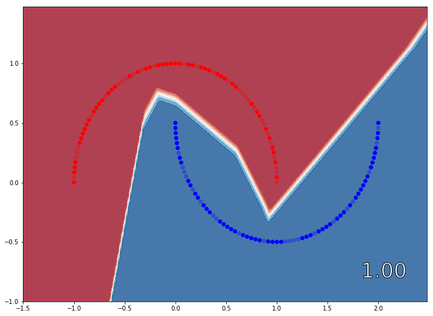

```python
fig, ax = plt.subplots()
plot_data(ax, (training_moon_p, training_moon_l),
          (testing_moon_p, testing_moon_l), clf, 'ann')
```

```python
clf = MLPClassifier(solver='lbfgs', alpha=1e-5, hidden_layer_sizes=(15, 15), random_state=12345)
clf.fit(training_circ_p, training_circ_l)
HTML('<h3> Testing data accuracy: ' + str(clf.score(testing_circ_p, testing_circ_l)) + '</h3>')
```

Testing data accuracy: 1.0

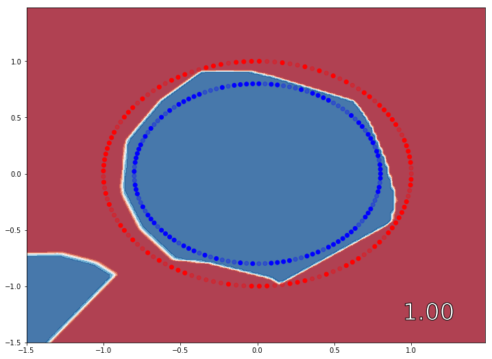

```python
fig, ax = plt.subplots()
plot_data(ax, (training_circ_p, training_circ_l),
          (testing_circ_p, testing_circ_l), clf, 'ann')
```

```python
clf = MLPClassifier(solver='lbfgs', alpha=1e-5, hidden_layer_sizes=(15, 15), random_state=12345)
clf.fit(training_spir_p, training_spir_l)
HTML('<h3> Testing data accuracy: ' + str(clf.score(testing_spir_p, testing_spir_l)) + '</h3>')
```

Testing data accuracy: 0.4864864864864865

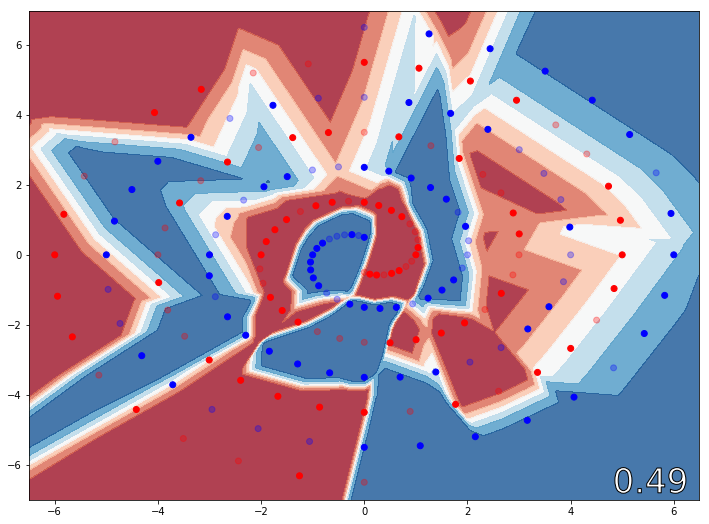

```python
fig, ax = plt.subplots()
plot_data(ax, (training_spir_p, training_spir_l),
          (testing_spir_p, testing_spir_l), clf, 'ann')
```

```python
clf = MLPClassifier(solver='lbfgs', alpha=1e-5, hidden_layer_sizes=(15,15), random_state=12345)
clf.fit(points, labels)
HTML('<h3> Testing data accuracy: ' + str(clf.score(testing_spir_p, testing_spir_l)) + '</h3>')
```

Testing data accuracy: 0.6756756756756757

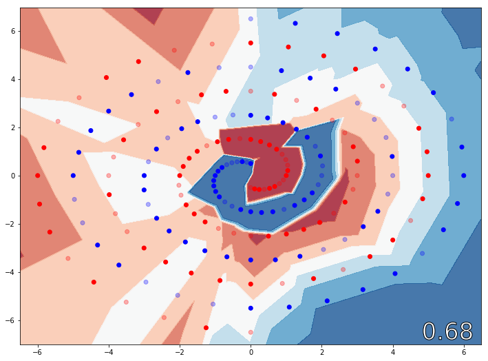

```python
fig, ax = plt.subplots()
plot_data(ax, (training_spir_p, training_spir_l),
             (testing_spir_p, testing_spir_l), clf, 'ann')
```

```python
np.random.seed(4375689)

from keras.models import Sequential
from keras.layers import Dense
from keras.optimizers import RMSprop

train_X = points
train_y = labels

model = Sequential()
model.add(Dense(16, activation='relu', input_shape=(2,)))
model.add(Dense(16, activation='relu'))
model.add(Dense(16, activation='relu'))
model.add(Dense(16, activation='relu'))
model.add(Dense(1, activation='sigmoid'))

model.compile(loss='binary_crossentropy', optimizer=RMSprop(),
              metrics=['accuracy'])

history = model.fit(train_X, train_y, batch_size=32, epochs=4000, verbose=0)

score = model.evaluate(train_X, train_y, verbose=0)
```

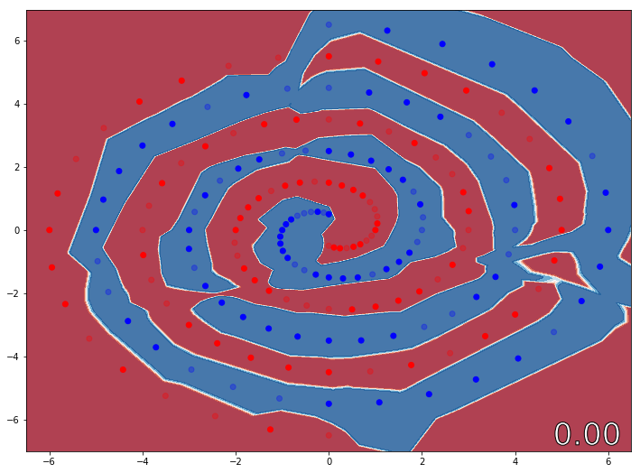

```python
fig, ax = plt.subplots()
plot_data(ax, (training_spir_p, training_spir_l),
             (testing_spir_p, testing_spir_l), model, 'keras')
```

# Results summary

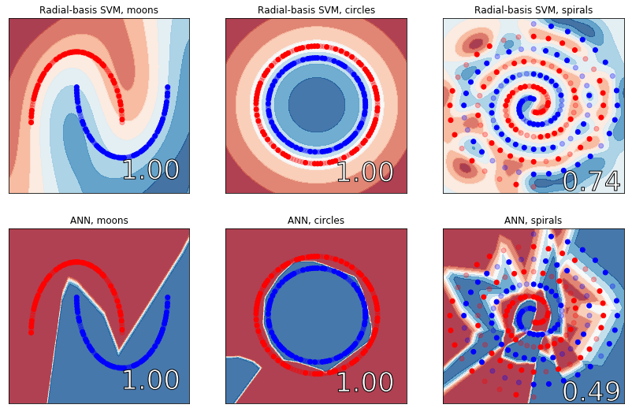

```python
summary_ann()
```

# Decision Trees

Decision trees reach a decision by performing a number of tests on the attributes (components of **x**), with branches representing value of attributes and leaves representing decision returned by the tree

```python
clf = tree.DecisionTreeClassifier(random_state=12345)
clf.fit(training_moon_p, training_moon_l)
HTML('<h3> Testing data accuracy: ' + str(clf.score(testing_moon_p, testing_moon_l)) + '</h3>')
```

Testing data accuracy: 1.0

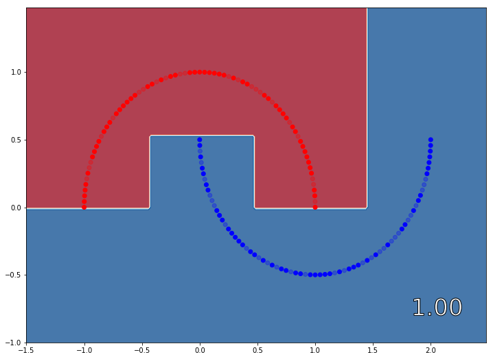

```python
fig, ax = plt.subplots()
plot_data(ax,
          (training_moon_p, training_moon_l),
          (testing_moon_p, testing_moon_l), clf, 'ann')
```

```python
dtree = tree.export_graphviz(clf, out_file=None,
                            feature_names=['x', 'y'],
                            class_names = ['red', 'blue'],
                            filled=True, rounded=True,
                            special_characters=True)
graph = graphviz.Source(dtree)
```

```python
graph
```

[figure not shown]

```python
clf = tree.DecisionTreeClassifier(random_state=12345)
clf.fit(training_circ_p, training_circ_l)
HTML('<h3> Testing data accuracy: ' + str(clf.score(testing_circ_p, testing_circ_l)) + '</h3>')
```

Testing data accuracy: 0.94

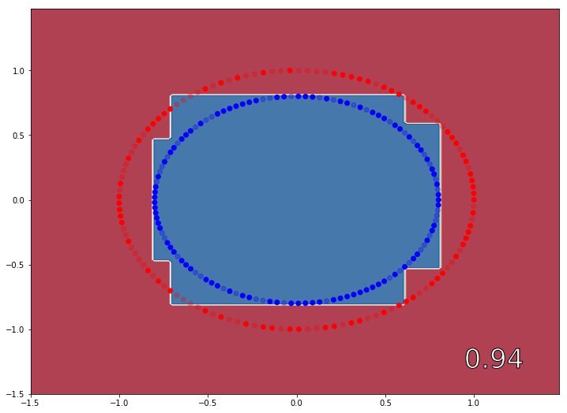

```python
fig, ax = plt.subplots()
plot_data(ax,
          (training_circ_p, training_circ_l),
          (testing_circ_p, testing_circ_l), clf, 'ann')
```

```python
clf = tree.DecisionTreeClassifier(random_state=12345)
clf.fit(training_spir_p, training_spir_l)
HTML('<h3> Testing data accuracy: ' + str(clf.score(testing_spir_p, testing_spir_l)) + '</h3>')
```

Testing data accuracy: 0.6216216216216216

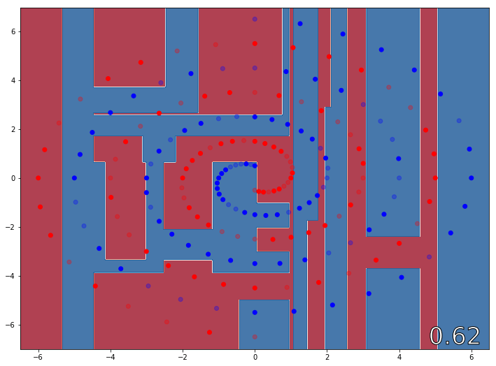

```python
fig, ax = plt.subplots()
plot_data(ax,
          (training_spir_p, training_spir_l),
          (testing_spir_p, testing_spir_l), clf, 'ann')
```

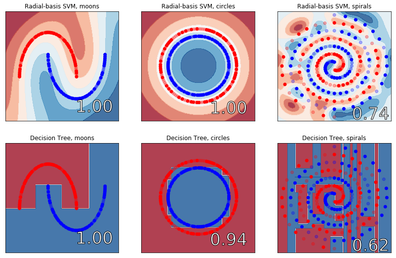

```python
summary_dtree()
```

# Hybrid and Multi-Classifier Systems

Multiple classifiers can also be combined together, either in parallel or sequentially, in order to achieve higher combined accuracy than that of the individual classifiers.

[figure not shown]

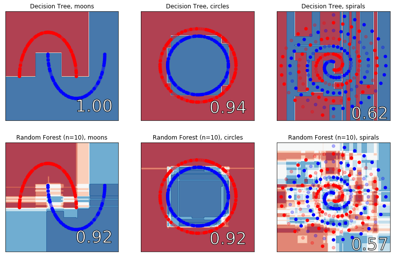

```python
summary_forest()
```

# Useful Resources

## Data Analysis in Python

- [Numpy](http://www.numpy.org/) (and [Scipy](https://www.scipy.org/) in general) (with a useful tutorial [here](http://www.scipy-lectures.org/))
- [Pandas](https://pandas.pydata.org/) provides R-like data frames for Python
- [Matplotlib](https://matplotlib.org/) is great for plotting and has an interface similar to MATLAB's plotting functions, and [Seaborn](https://seaborn.pydata.org/) provides plotting for statistics specifically

## Machine Learning

- [Scikit-learn](http://scikit-learn.org/stable/) is an easy place to start if you are just looking to try out a few algorithms and see what happens
- [Keras](https://keras.io/) is probably the easiest library to pick up for ANNs
- [TensorFlow](https://www.tensorflow.org/) is very versatile, but can take a bit of time to really get to grips with